# 中国COVID-19 疫情监测数据的时间趋势分析

wuzhaoyang

2026-07-10

## 1.研究背景、目的和意义

### 1.1研究背景

COVID-19是近年来对全球公共卫生体系造成重大冲击的突发性传染病事件，其传播范围广、传播速度快，对社会运行与医疗资源配置产生了深远影响。疫情监测数据能够系统性地反映感染病例在时间与空间上的动态变化，是刻画疫情发展过程的重要基础信息。通过对疫情数据进行时间趋势分析，可以识别疫情上升、平台期与下降等阶段性变化规律，从而更好地理解疫情传播机制，并为疫情监测预警与公共卫生防控决策提供科学依据。

### 1.3研究意义

本研究的意义在于，一方面通过时空演变分析丰富了突发传染病流行病学的实证研究体系，为理解疫情的空间异质性提供了科学依据；另一方面，本研究量化评估了非药物干预措施（NPIs）的实际防控成效，能够为相关部门优化传染病监测预警体系、科学配置公共卫生资源以及完善跨区域联动防控机制提供重要的决策支持与参考路径。

## 2.资料来源与研究方法

### 2.1数据来源

本研究选取的数据涵盖 2020年1月至7月中国内地31个省的 COVID-19 每日监测记录，所有原始数据均直接采集自中华人民共和国国家卫生健康委员会及各省级卫生健康委员会官方发布的每日疫情通报，以确保数据的权威性、时效性及口径的一致性，从而构建起反映疫情早期全生命周期的时序数据集。

## 3.结果

### 3.1导入并处理原始数据

```r
library(readxl)
library(dplyr)
library(lubridate)
library(ggplot2)
library(grid)
library(ggpubr)
library(gridExtra)
# 设置中文显示（Windows系统）
options(encoding = "UTF-8")
par(family = "SimHei")
windowsFonts(ST = windowsFont("SimHei"))
theme_set(theme_bw() + theme(text = element_text(family = "ST")))
df_raw <- read_excel("china_provincedata.xlsx")
# 读取后用dateId转换生成date列
df_raw$date <- ymd(df_raw$dateId)

# 筛选2020-01-01 ~ 2020-07-31
df <- df_raw %>%
  filter(date >= ymd("2020-01-01") & date <= ymd("2020-07-31")) %>%
  arrange(date)
rownames(df) <- NULL

# 按日期聚合全国数据
national_df <- df %>%
  group_by(date) %>%
  summarise(
    confirmedIncr = sum(confirmedIncr),   # 新增确诊
    confirmedCount = sum(confirmedCount), # 累计确诊
    curedCount = sum(curedCount),         # 累计治愈
    deadCount = sum(deadCount),           # 累计死亡
    .groups = "drop"
  )

# 重命名列名
colnames(national_df) <- c("date", "新增确诊", "累计确诊", "累计治愈", "累计死亡")

# 计算日增长率
national_df <- national_df %>%
  mutate(
    prev_confirmed = lag(`累计确诊`),
    daily_growth_rate = `新增确诊` / prev_confirmed
  ) %>%
  mutate(daily_growth_rate = ifelse(is.na(daily_growth_rate), 0, daily_growth_rate))
```

### 3.2绘制双Y轴趋势图

#### 3.2.1左Y轴（累计类）

```r
p <- ggplot() +
  geom_line(data = national_df, aes(x = date, y = `累计确诊`, color = "累计确诊"), linewidth = 1.2) +
  geom_line(data = national_df, aes(x = date, y = `累计治愈`, color = "累计治愈"), linewidth = 1.2) +
  geom_line(data = national_df, aes(x = date, y = `累计死亡`, color = "累计死亡"), linewidth = 1.2) +
  scale_color_manual(
    name = "",
    values = c(
      "累计确诊" = "#0070C0",
      "累计治愈" = "#00B050",
      "累计死亡" = "#C00000"
    )
  ) +
  labs(
    title = "全国COVID-19疫情新增/累计确诊/治愈/死亡趋势图",
    x = "日期",
    y = "累计病例数"
  ) +
  theme(
    plot.title = element_text(face = "bold", size = 14, hjust = 0.5),
    axis.text.x = element_text(angle = 45, hjust = 1),
    legend.position = "top"
  )
```

#### 3.2.2右Y轴（新增确诊）

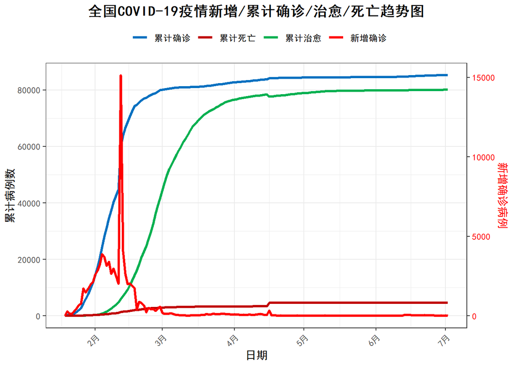

```r
max_cum <- max(national_df$`累计确诊`, na.rm = TRUE)
max_new <- max(national_df$`新增确诊`, na.rm = TRUE)
scale_factor <- max_cum / max_new

p <- p +
  geom_line(
    data = national_df,
    aes(x = date, y = `新增确诊` * scale_factor, color = "新增确诊"),
    linewidth = 1.2
  ) +
  scale_y_continuous(
    name = "累计病例数",
    sec.axis = sec_axis(~ . / scale_factor, name = "新增确诊病例")
  ) +
  scale_color_manual(
    name = "",
    values = c(
      "累计确诊" = "#0070C0",
      "累计治愈" = "#00B050",
      "累计死亡" = "#C00000",
      "新增确诊" = "#FF0000"
    )
  ) +
  theme(
    axis.title.y.right = element_text(color = "#FF0000"),
    axis.text.y.right = element_text(color = "#FF0000")
  )
print(p)
```

```r
cat("✅ 双Y轴总趋势图绘制完成\n")
```

```
## ✅ 双Y轴总趋势图绘制完成
```

### 3.3全国每日新增

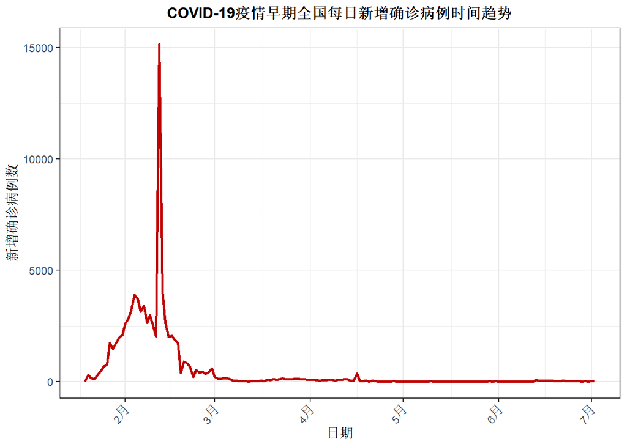

```r
p1 <- ggplot(national_df, aes(x = date, y = `新增确诊`)) +
  geom_line(color = "#C00000", linewidth = 1) +
  labs(
    title = "COVID-19疫情早期全国每日新增确诊病例时间趋势",
    x = "日期", y = "新增确诊病例数"
  ) +
  theme_bw() +
  theme(
    plot.title = element_text(face = "bold", size = 12, hjust = 0.5),
    axis.text.x = element_text(angle = 45, hjust = 1),
    panel.grid.y = element_line(linetype = "dashed", alpha = 0.7)
  )
print(p1)
```

### 3.4全国累计S型曲线

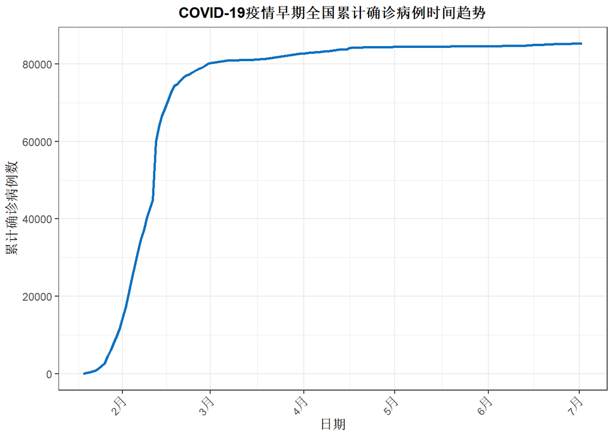

```r
p2 <- ggplot(national_df, aes(x = date, y = `累计确诊`)) +
  geom_line(color = "#0070C0", linewidth = 1) +
  labs(
    title = "COVID-19疫情早期全国累计确诊病例时间趋势",
    x = "日期", y = "累计确诊病例数"
  ) +
  theme_bw() +
  theme(
    plot.title = element_text(face = "bold", size = 12, hjust = 0.5),
    axis.text.x = element_text(angle = 45, hjust = 1),
    panel.grid.y = element_line(linetype = "dashed", alpha = 0.7)
  )
print(p2)
```

### 3.5重点省份新增对比

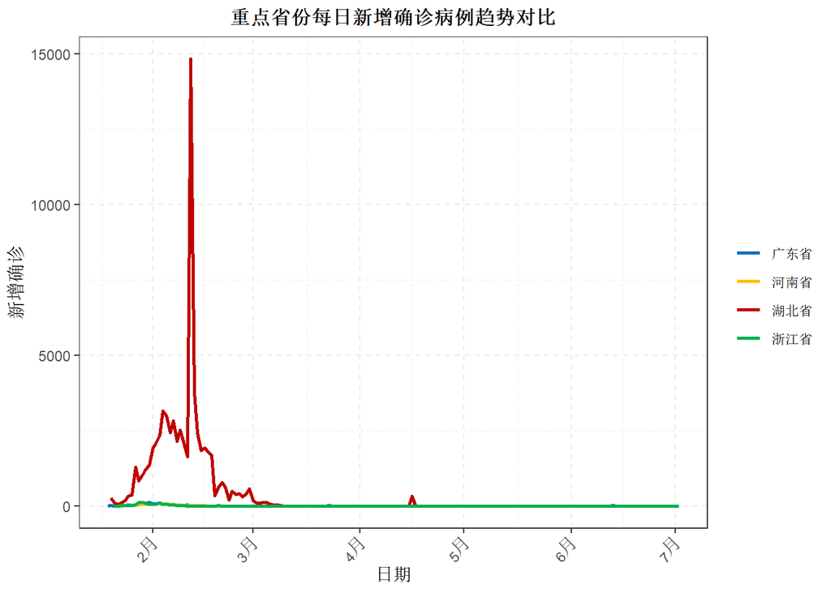

```r
target_provinces <- c("湖北省", "广东省", "浙江省", "河南省")
province_df <- df %>% filter(provinceName %in% target_provinces)
province_daily <- province_df %>%
  group_by(provinceName, date) %>%
  summarise(confirmedIncr = sum(confirmedIncr), .groups = "drop")

province_colors <- c(
  "湖北省" = "#C00000",
  "广东省" = "#0070C0",
  "浙江省" = "#00B050",
  "河南省" = "#FFC000"
)

p4 <- ggplot(province_daily, aes(x = date, y = confirmedIncr, color = provinceName)) +
  geom_line(linewidth = 1) +
  scale_color_manual(values = province_colors) +
  labs(
    title = "重点省份每日新增确诊病例趋势对比",
    x = "日期", y = "新增确诊", color = ""
  ) +
  theme_bw() +
  theme(
    plot.title = element_text(face = "bold", size = 12, hjust = 0.5),
    axis.text.x = element_text(angle = 45, hjust = 1),
    panel.grid = element_line(linetype = "dashed", alpha = 0.7)
  )
print(p4)
```

### 3.6疫情日增长率

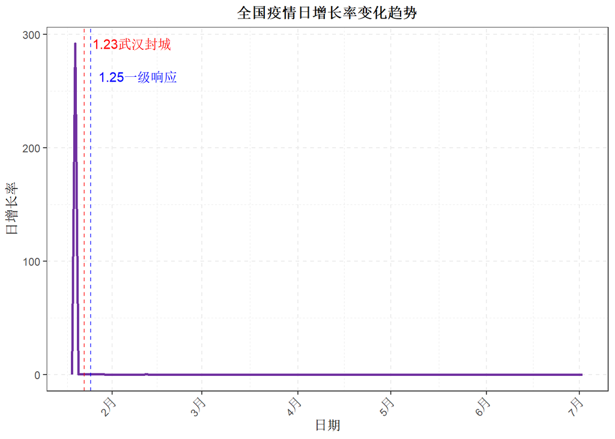

```r
p5 <- ggplot(national_df, aes(x = date, y = daily_growth_rate)) +
  geom_line(color = "#7030A0", linewidth = 1) +
  geom_vline(xintercept = ymd("2020-01-23"), color = "red", linetype = "dashed", alpha = 0.7) +
  geom_vline(xintercept = ymd("2020-01-25"), color = "blue", linetype = "dashed", alpha = 0.7) +
  annotate("text", x = ymd("2020-01-23"), y = max(national_df$daily_growth_rate, na.rm = T),
           label = "1.23武汉封城", color = "red", hjust = -0.1) +
  annotate("text", x = ymd("2020-01-25"), y = max(national_df$daily_growth_rate, na.rm = T)*0.9,
           label = "1.25一级响应", color = "blue", hjust = -0.1) +
  labs(
    title = "全国疫情日增长率变化趋势",
    x = "日期", y = "日增长率"
  ) +
  theme_bw() +
  theme(
    plot.title = element_text(face = "bold", size = 12, hjust = 0.5),
    axis.text.x = element_text(angle = 45, hjust = 1),
    panel.grid = element_line(linetype = "dashed", alpha = 0.7)
  )
print(p5)
```

### 3.7疫情阶段总结表格

```r
cat("\n===== 趋势阶段总结 =====\n")
```

```
##
## ===== 趋势阶段总结 =====
```

```r
summary_df <- data.frame(
  阶段 = c("① 快速增长", "② 达到峰值", "③ 持续下降", "④ 基本控制"),
  时间 = c("2020年1月", "2020年2月", "2020年3月", "2020年4-7月")
)
print(summary_df)
```

```
##         阶段        时间
## 1 ① 快速增长   2020年1月
## 2 ② 达到峰值   2020年2月
## 3 ③ 持续下降   2020年3月
## 4 ④ 基本控制 2020年4-7月
```

### 3.8高发省份对比

```r
library(scales)
windowsFonts(ST = windowsFont("SimHei"))
theme_set(theme_bw() + theme(text = element_text(family = "ST")))
df_raw <- read_excel("china_provincedata.xlsx")
df_raw$date <- as.Date(as.character(df_raw$dateId), format = "%Y%m%d")
df <- subset(df_raw, date >= "2020-01-01" & date <= "2020-07-31")
names(df)[names(df) == "provinceName"] <- "省份"
names(df)[names(df) == "confirmedIncr"] <- "新增确诊"
names(df)[names(df) == "confirmedCount"] <- "累计确诊"
names(df)[names(df) == "curedCount"] <- "累计治愈"
names(df)[names(df) == "deadCount"] <- "累计死亡"
province_list <- c(
  "北京市", "天津市", "河北省", "山西省", "内蒙古自治区",
  "辽宁省", "吉林省", "黑龙江省", "上海市", "江苏省",
  "浙江省", "安徽省", "福建省", "江西省", "山东省",
  "河南省", "湖北省", "湖南省", "广东省", "广西壮族自治区",
  "海南省", "重庆市", "四川省", "贵州省", "云南省",
  "西藏自治区", "陕西省", "甘肃省", "青海省", "宁夏回族自治区", "新疆维吾尔自治区"
)
df <- subset(df, 省份 %in% province_list)
prov_max <- aggregate(累计确诊 ~ 省份, data = df, FUN = max)
high_prov <- subset(prov_max, 累计确诊 >= 1000)$省份   # 高发病省份
low_prov  <- subset(prov_max, 累计确诊 < 1000)$省份    # 低发病省份
cat("高发病省份(累计≥1000)：", high_prov, "\n")
```

```
## 高发病省份(累计≥1000)： 广东省 河南省 湖北省 湖南省 浙江省
```

```r
cat("低发病省份(累计<1000)：", low_prov, "\n")
```

```
## 低发病省份(累计<1000)： 安徽省 北京市 福建省 甘肃省 广西壮族自治区 贵州省 海南省 河北省 黑龙江省 吉林省 江苏省 江西省 辽宁省 内蒙古自治区 宁夏回族自治区 青海省 山东省 山西省 陕西省 上海市 四川省 天津市 西藏自治区 新疆维吾尔自治区 云南省 重庆市
```

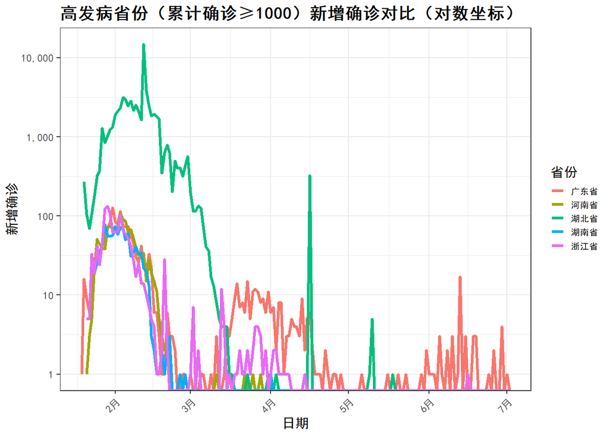

```r
plot_fig <- function(data_all, prov_set, col_name, title_text){
  # 筛选目标省份数据
  plot_dt <- subset(data_all, 省份 %in% prov_set)
  p <- ggplot(plot_dt, aes(x = date, y = .data[[col_name]], color = 省份)) +
    geom_line(linewidth = 1.2) +
    scale_y_log10(labels = comma) +  # 对数坐标轴，区分小数值
    labs(
      title = title_text,
      x = "日期",
      y = col_name
    ) +
    theme(
      plot.title = element_text(size = 14, face = "bold"),
      axis.text.x = element_text(angle = 45, hjust = 1),
      legend.text = element_text(size = 7),
      legend.key.size = unit(0.4, "cm")
    )
  print(p)
}
# 图1 新增确诊
plot_fig(df, high_prov, "新增确诊", "高发病省份（累计确诊≥1000）新增确诊对比（对数坐标）")
```

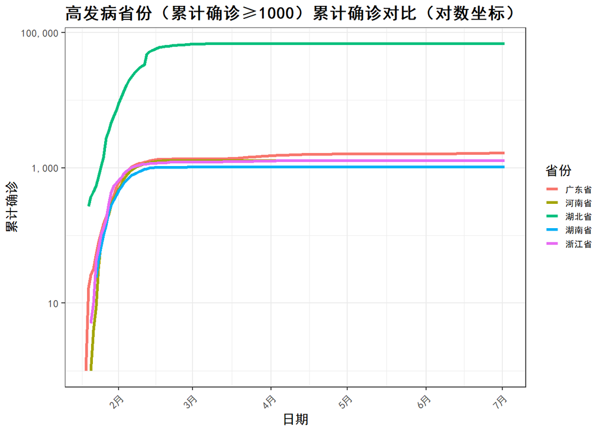

```r
# 图2 累计确诊
plot_fig(df, high_prov, "累计确诊", "高发病省份（累计确诊≥1000）累计确诊对比（对数坐标）")
```

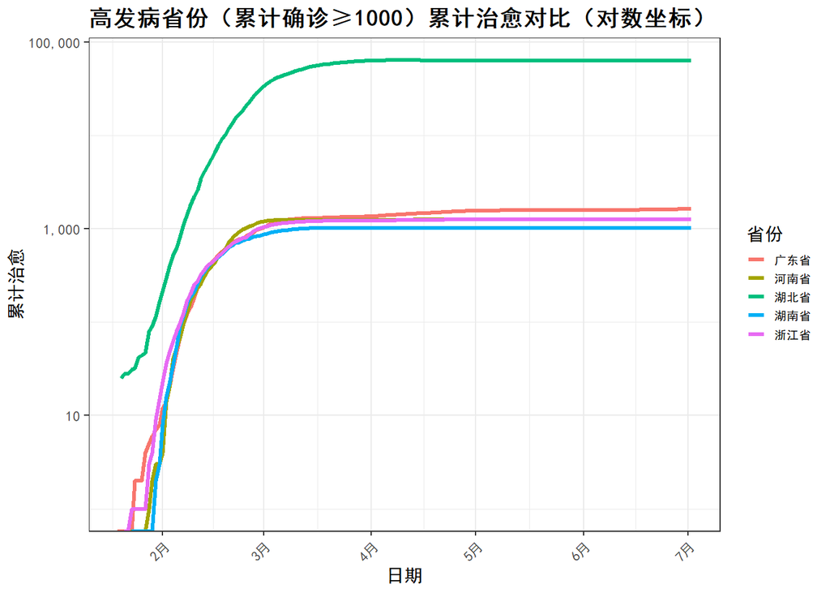

```r
# 图3 累计治愈
plot_fig(df, high_prov, "累计治愈", "高发病省份（累计确诊≥1000）累计治愈对比（对数坐标）")
```

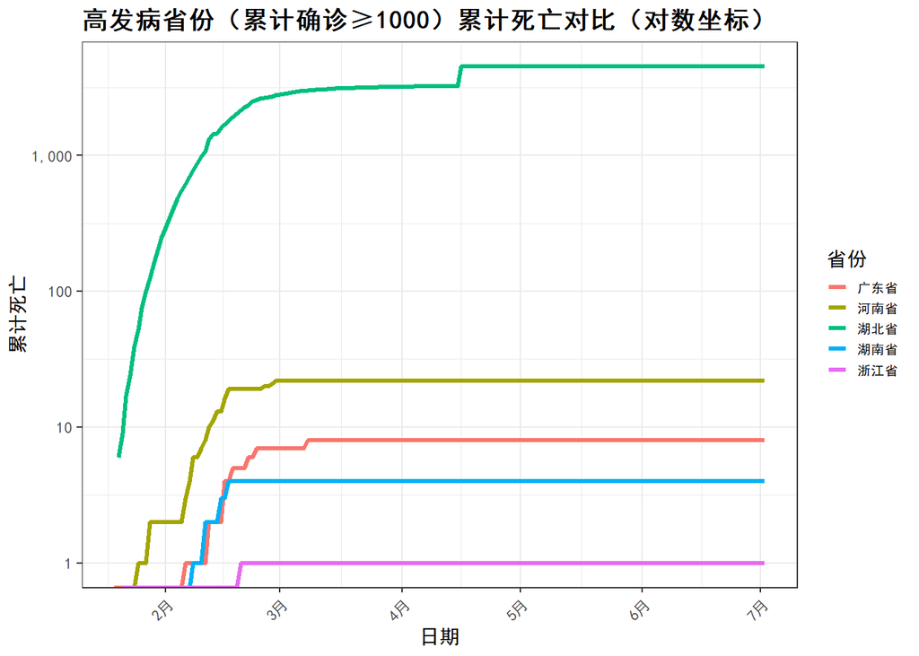

```r
# 图4 累计死亡
plot_fig(df, high_prov, "累计死亡", "高发病省份（累计确诊≥1000）累计死亡对比（对数坐标）")
```

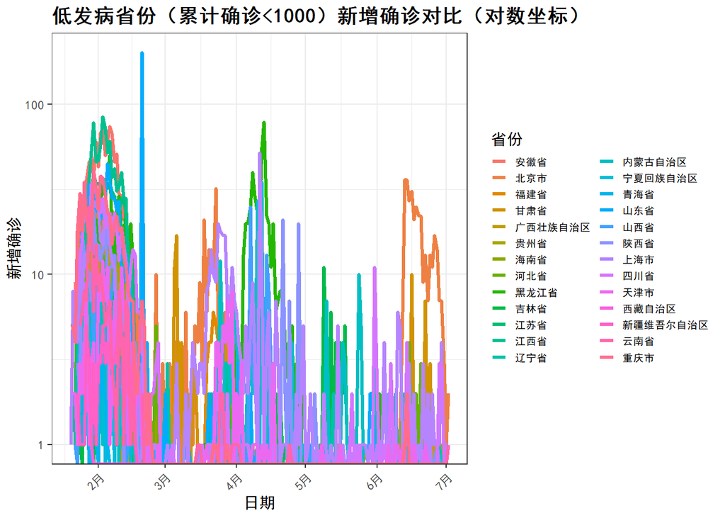

```r
# 图5 新增确诊
plot_fig(df, low_prov, "新增确诊", "低发病省份（累计确诊<1000）新增确诊对比（对数坐标）")
```

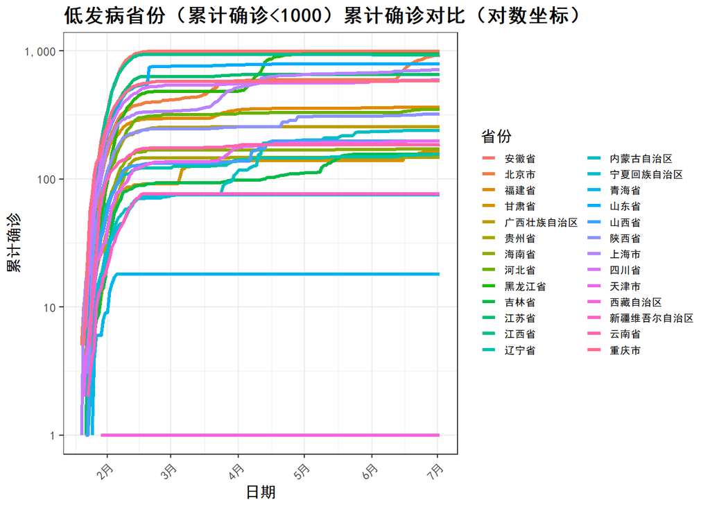

```r
# 图6 累计确诊
plot_fig(df, low_prov, "累计确诊", "低发病省份（累计确诊<1000）累计确诊对比（对数坐标）")
```

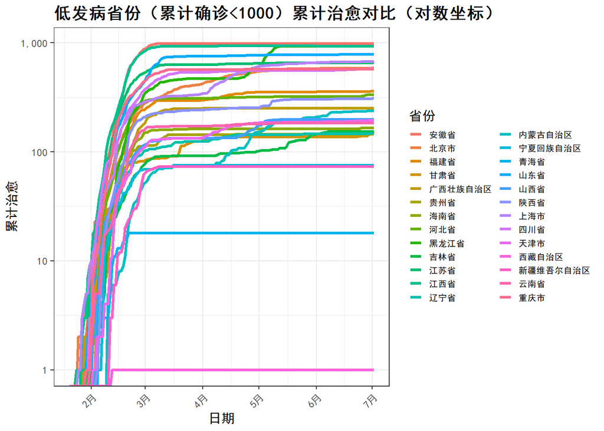

```r
# 图7 累计治愈
plot_fig(df, low_prov, "累计治愈", "低发病省份（累计确诊<1000）累计治愈对比（对数坐标）")
```

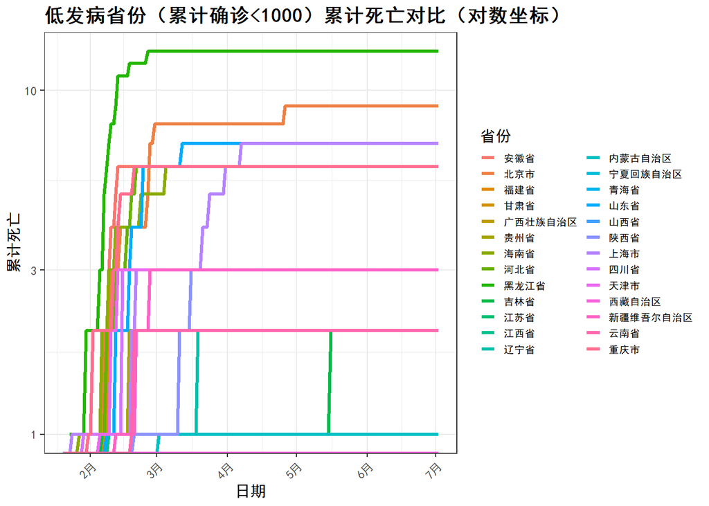

```r
# 图8 累计死亡
plot_fig(df, low_prov, "累计死亡", "低发病省份（累计确诊<1000）累计死亡对比（对数坐标）")
```

```r
cat("8张图表全部绘制完成\n")
```

```
## 8张图表全部绘制完成
```

## 4.结果解释

### 4.1疫情早期全国每日新增确诊病例时间趋势

结果显示：2020年1月至7月全国COVID-19新增确诊病例数呈现明显的阶段性演变。疫情早期（1月下旬）病例数呈爆发式增长，并在2月中旬达到峰值，这与当时湖北省大规模病例筛查及统计口径调整密切相关。随后，随着防控措施的全面升级，每日新增病例数迅速下降，并在3月初降至低位水平，进入长期平稳的常态化防控阶段。

### 4.2疫情早期全国累计确诊病例时间趋势

结果显示：1月至2月底曲线陡峭快速上扬，对应疫情集中暴发阶段，人员流动引发多地输入病例，累计确诊数量快速攀升；3月至4月曲线坡度明显放缓，得益于武汉封城、全国一级公共卫生响应、社区隔离等防控措施落地，病毒传播链被切断，新增病例大幅减少，累计病例增长速度持续收窄；5月至7月曲线趋于水平稳定，累计确诊总量维持在8万至 8.5 万区间，本土传播基本阻断，仅存在少量境外输入零星病例，国内本土疫情基本得到全面控制，直观体现出早期各项公共卫生干预手段对抑制疫情扩散、阻断病例持续增长起到了显著效果。

## 5.局限性

仅统计 2020 年 1—7月早期数据，无法反映下半年境外输入、局部复发等后续疫情变化，时间覆盖范围有限。仅分析确诊、治愈、死亡数量，未纳入人口基数、医疗资源、人员流动、防控政策实施时序等混杂变量，无法量化各地防控措施、人口密度对疫情规模的影响